# Gene and Cell QC

NadineBestard

27/02/2021

# Set-up

```r
library(here) # for reproducible paths
library(SingleCellExperiment)
library(scater) # For qcs
library(org.Mm.eg.db) # To annotate the genenames
```

```r
sce <- readRDS(here("processed", "sce_young.RDS"))
project <- "delete-2660"
```

The object has 32285 genes and 90750 cells before filtering

# Add cell QC metrics to the sce

First we need to sort the gene names and gene symbols, because the default ensembl notation is not very handy. And then save the mitochondrial genes as such.

```r
if (!file.exists(here("processed", project, "sce_preliminary.RDS"))) {
  # obtain full genenames
  genename <- mapIds(org.Mm.eg.db,
                     keys = rownames(sce),
                     keytype = "ENSEMBL",
                     column = c("GENENAME")
                     )
  # Use the symbols as rownames
  # first make gene names unique
  # TODO: save duplicate gene name list
  symb_unique <- uniquifyFeatureNames(rownames(sce), rowData(sce)[, "Symbol"])
  # Now they can be used as rownames
  rownames(sce) <- symb_unique
  # Add full gene names and the uniuqe symbols to the rowdata
  rowData(sce)$symb_uniq <- symb_unique
  rowData(sce)$gene_name <- genename
  # Subset the mitochondrial genes
  is_mito <- grepl("^mt-", rownames(sce))
} else {
  sce <- readRDS(here( "processed", project, "sce_preliminary.RDS"))
}
```

Then we can use the scater package to add the quality per cell. This computes for each cell some useful metrics such as the number of umi counts (library size), the number of detected genes and the percentage of mitochondiral genes.

Then we use the automatic isOutlier function from the same package that determine which values in a numeric vector are outliers based on the median absolute deviation (MAD). When using this function with low number a log transformation is added, that prevents negative thresholds. We also take only in consideration the first three batches, as the last one is lower quality

```r
if (!file.exists(here( "processed", project, "sce_preliminary.RDS"))) {
  sce <- addPerCellQC(sce, subsets = list(mt = is_mito))

  # Automated outlier detection
  outlier_lib_low <- isOutlier(sce$total, log = TRUE, type = "lower", subset = sce$chip %in% c(3:5))
  outlier_expr_low <-
    isOutlier(sce$detected, log = TRUE, type = "lower", subset = sce$chip %in% c(3:5))
  outlier_lib_high <- isOutlier(sce$total, type = "higher")
  outlier_expr_high <-
    isOutlier(sce$detected, type = "higher")
  outlier_mt <- isOutlier(sce$subsets_mt_percent, type = "higher", subset = sce$chip %in% c(3:5))
  # total
  outlier <-
    outlier_lib_low |
      outlier_expr_low |
      outlier_lib_high | outlier_expr_high | outlier_mt

  # Visualize the thresholds and the cells deleted by each parametre
  summary_outlier <- data.frame(
    lib_size_high = c(sum(outlier_lib_high),
                      attr(outlier_lib_high, "thresholds")[2]),
    expression_high = c(sum(outlier_expr_high),
                        attr(outlier_expr_high, "thresholds")[2]),
    lib_size_low = c(sum(outlier_lib_low),
                     attr(outlier_lib_low, "thresholds")[1]),
    expression_low = c(sum(outlier_expr_low),
                       attr(outlier_expr_low, "thresholds")[1]),
    mt_pct = c(sum(outlier_mt), attr(outlier_mt, "thresholds")[2]),
    total = c(sum(outlier), NA)
  )
  row.names(summary_outlier) <- c("Cells filtered", "Threshold")
  write.csv(summary_outlier, here("outs", project, "autofilter_summary.csv"))
  # Add if it is an outlier to the metadata
  sce$outlier <- outlier
} else {
  summary_outlier <- read.csv(here("outs", project, "autofilter_summary.csv"))
}
summary_outlier
```

```
##                lib_size_high expression_high lib_size_low expression_low
## Cells filtered       3083.00          99.000       0.0000       4234.000
## Threshold           19023.52        7111.237     462.2212        428.559
##                     mt_pct total
## Cells filtered 18347.00000 23331
## Threshold         14.37436    NA
```

This data is saved in outs/delete-2660/autofilter_summary.csv # Plots before QC

Diagnostic plots to visualize the data distribution. The orange cells are marked as outliers by the automatic detection from scater.

### Violin plots

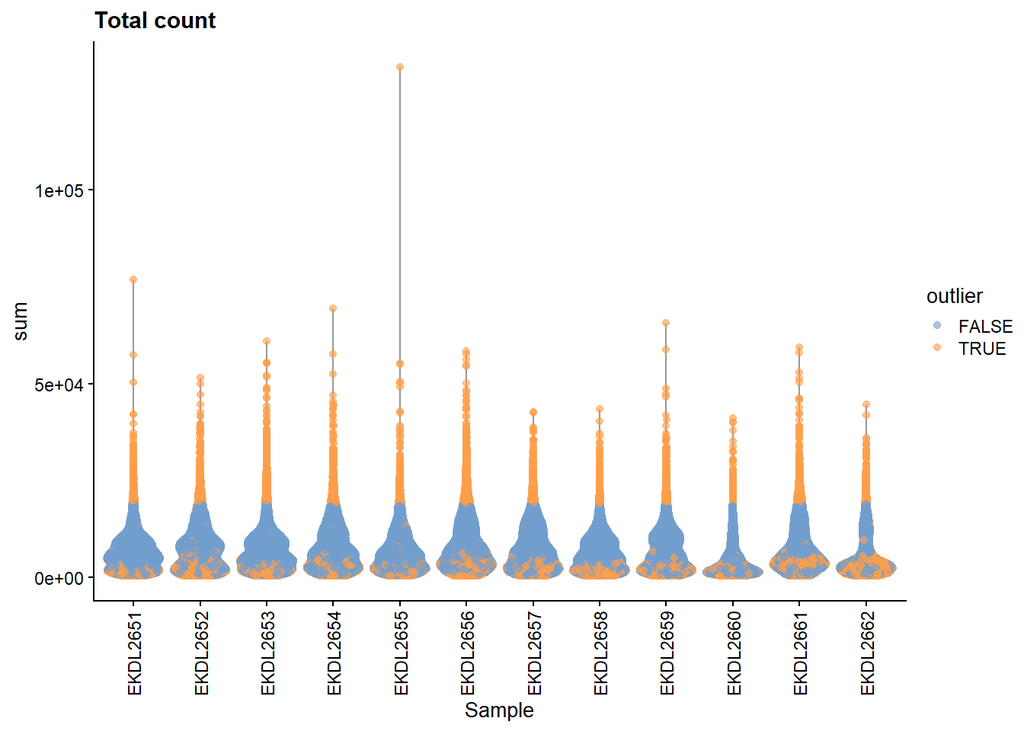

```r
plotColData(sce, x = "Sample", y = "sum", colour_by = "outlier") +
  ggtitle("Total count") +
  theme(axis.text.x = element_text(angle = 90, vjust = 0.5, hjust = 1))
```

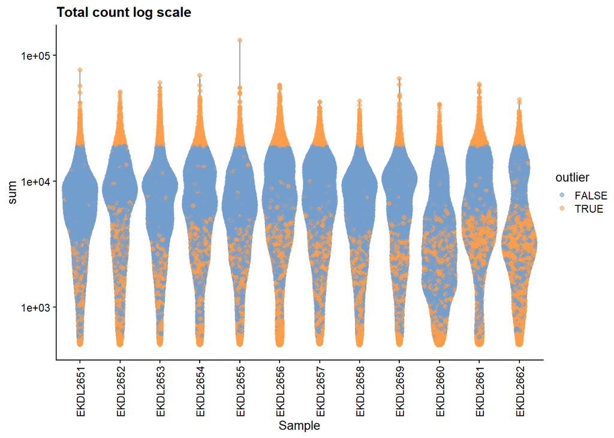

```r
plotColData(sce, x = "Sample", y = "sum", colour_by = "outlier") +
  scale_y_log10() + ggtitle("Total count log scale") +
  theme(axis.text.x = element_text(angle = 90, vjust = 0.5, hjust = 1))
```

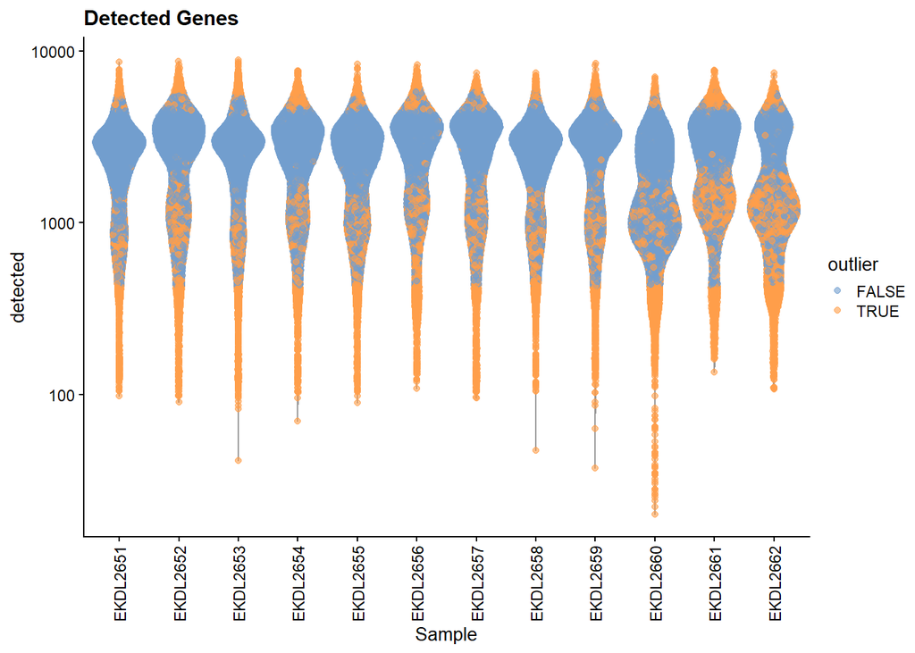

```r
plotColData(sce, x = "Sample", y = "detected", colour_by = "outlier") +
  scale_y_log10() + ggtitle("Detected Genes") +
  theme(axis.text.x = element_text(angle = 90, vjust = 0.5, hjust = 1))
```

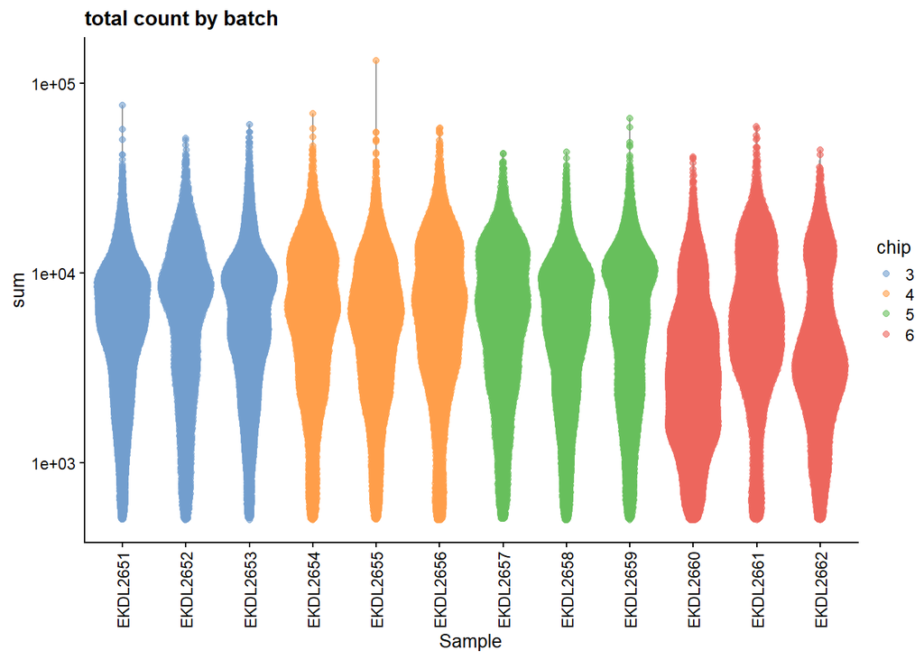

```r
plotColData(sce, x = "Sample", y = "sum", colour_by = "chip") +
  scale_y_log10() + ggtitle("total count by batch") +
  theme(axis.text.x = element_text(angle = 90, vjust = 0.5, hjust = 1))
```

We can see how chip 6 has a greater amount of cells with lower umi counts than the other 3. This chip has not been taken in consideration when calculating the overall thresholds.

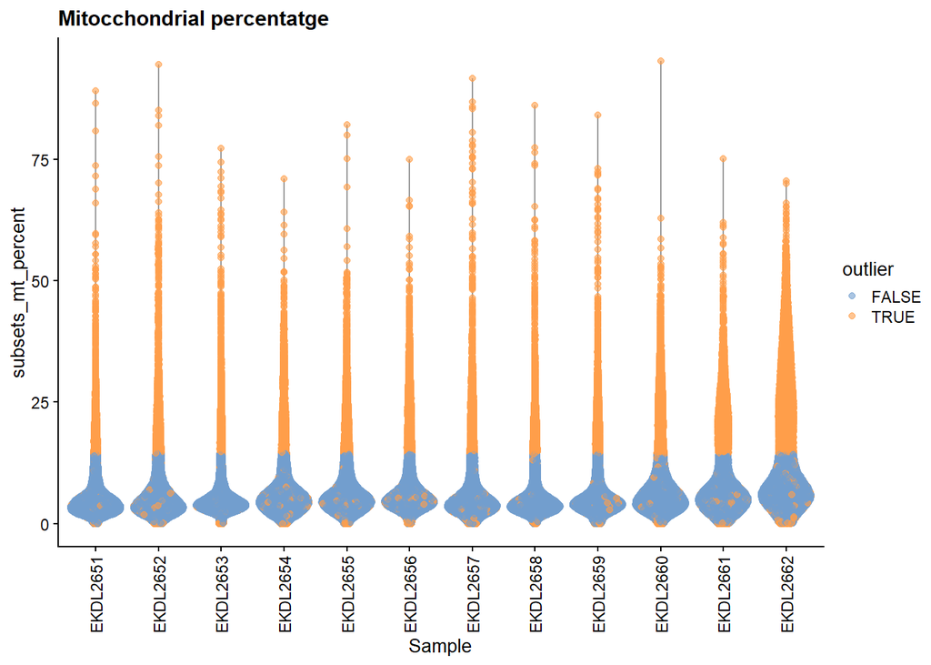

```r
plotColData(sce, x = "Sample", y = "subsets_mt_percent", colour_by = "outlier") +
  ggtitle("Mitocchondrial percentatge") +
  theme(axis.text.x = element_text(angle = 90, vjust = 0.5, hjust = 1))
```

### Histograms

In the x axis we can see the total number of umi (library size) per cell, the number of detected genes per cell and the mitochondrial percentage per cell; with the number of cells for each measure in the y axis.

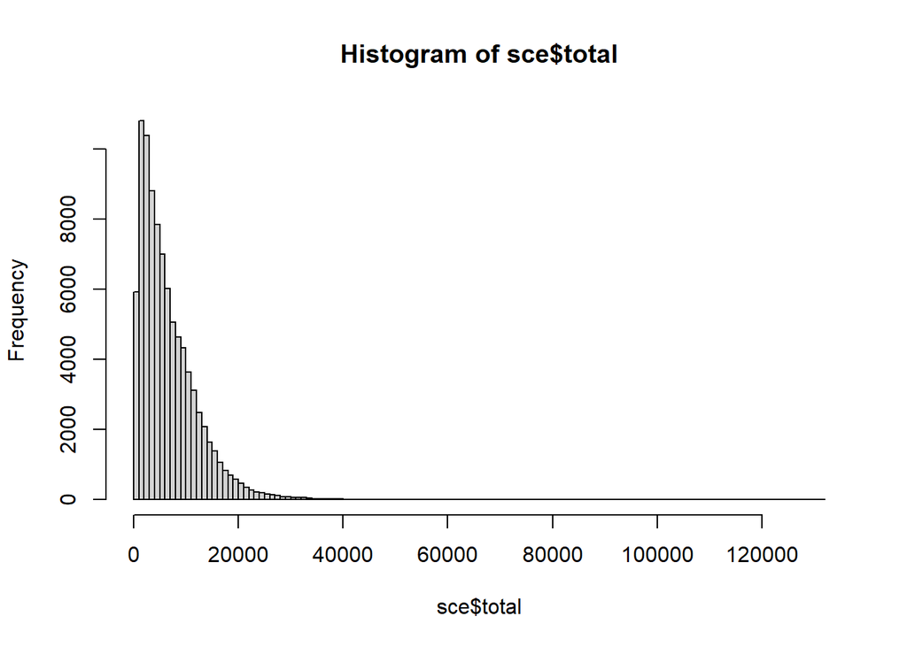

```r
hist(
  sce$total,
  breaks = 100
)
```

This object had already been filtrated with the cell-calling algorithm from CellRanger, that is meant to remove empty droplets. Therefore it is expected to see the total sum of umi skewed as in the plot above.

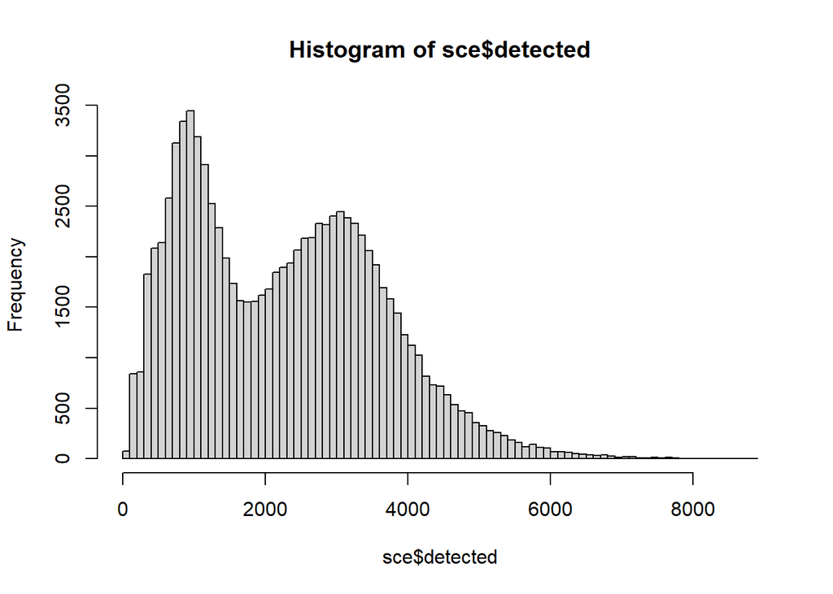

```r
hist(
  sce$detected,
  breaks = 100
)
```

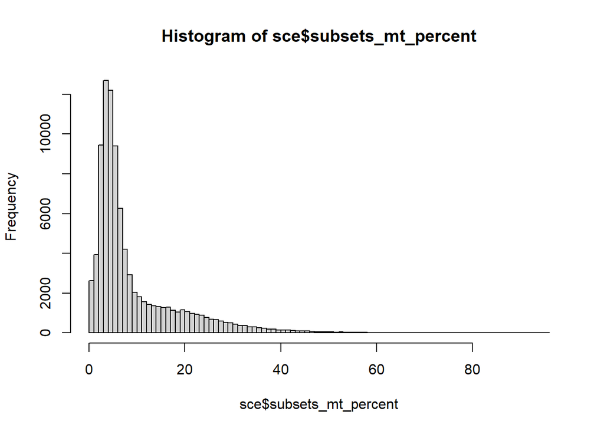

```r
hist(
  sce$subsets_mt_percent,
  breaks = 100
)
```

There is a very heavy tail of cells with high mitochondrial genes.

### Scatter plots

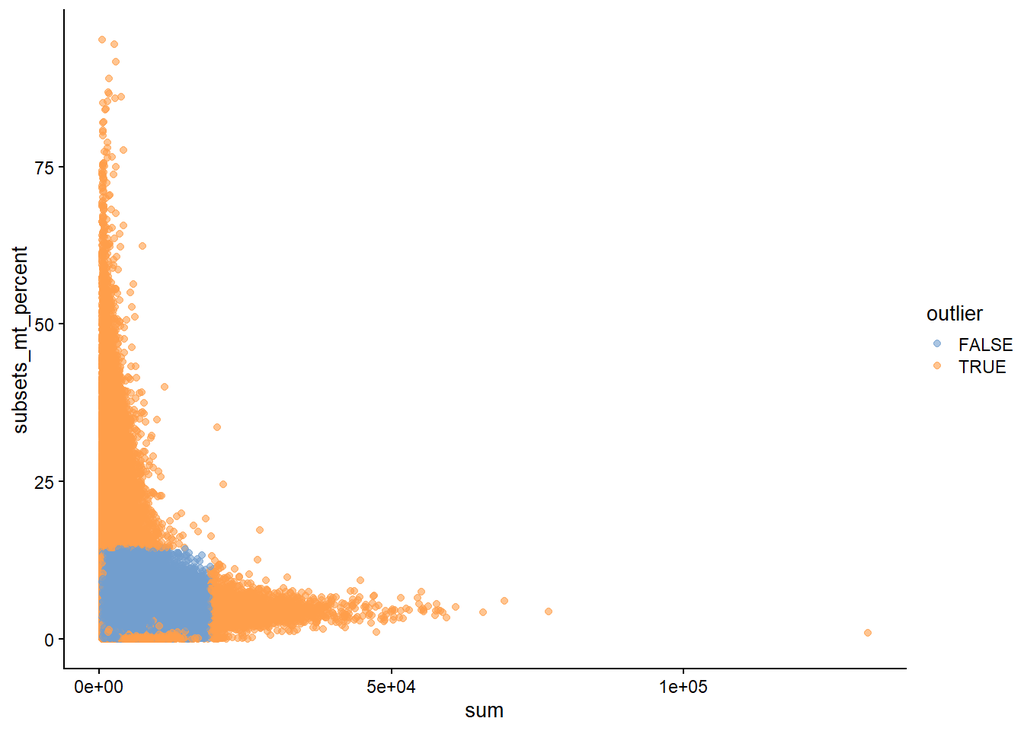

```r
plotColData(sce, x = "sum", y = "subsets_mt_percent", colour_by = "outlier")
```

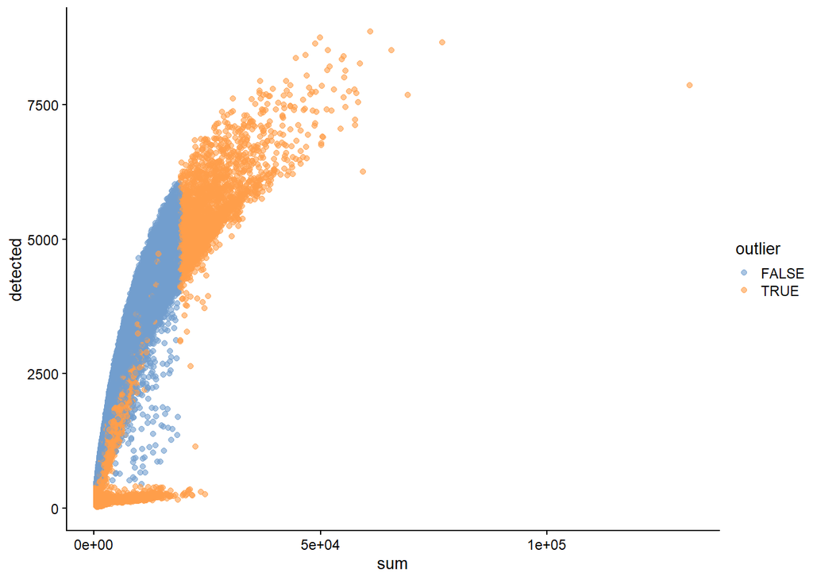

```r
plotColData(sce, x = "sum", y = "detected", colour_by = "outlier")
```

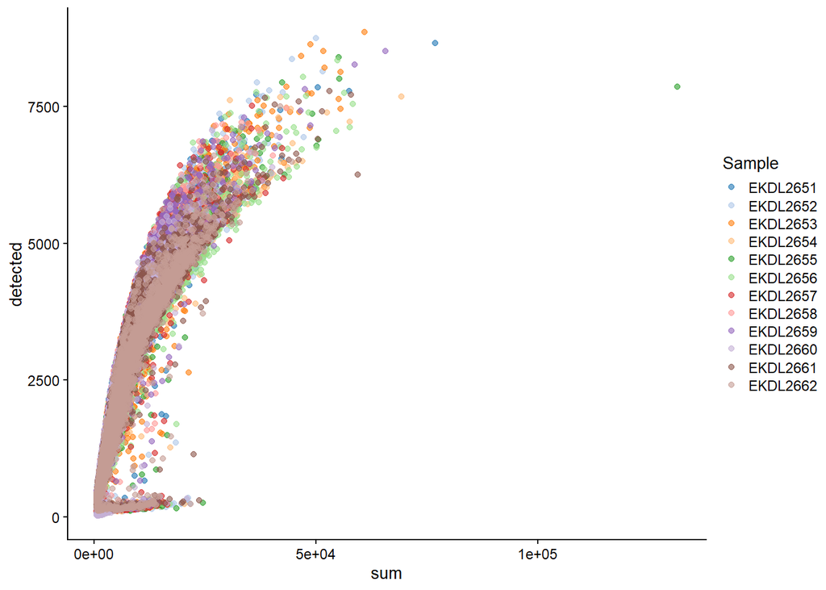

```r
plotColData(sce, x = "sum", y = "detected", colour_by = "Sample")
```

### PCA

Here we run a PCA using the information in the metadata instead of the gene expression. It is useful to visualize the QC parametres.

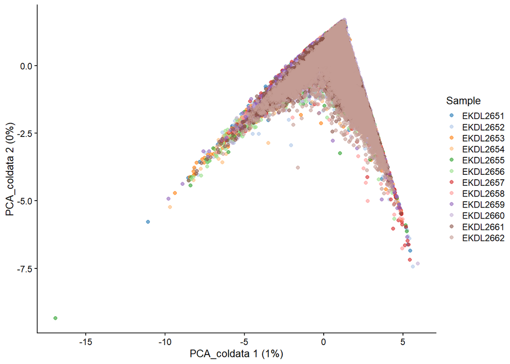

```r
if (!file.exists(here( "processed", project, "sce_preliminary.RDS"))) {
  sce <- runColDataPCA(sce, variables = c("sum", "detected", "subsets_mt_percent"))
}
plotReducedDim(sce, dimred = "PCA_coldata", colour_by = "Sample")
```

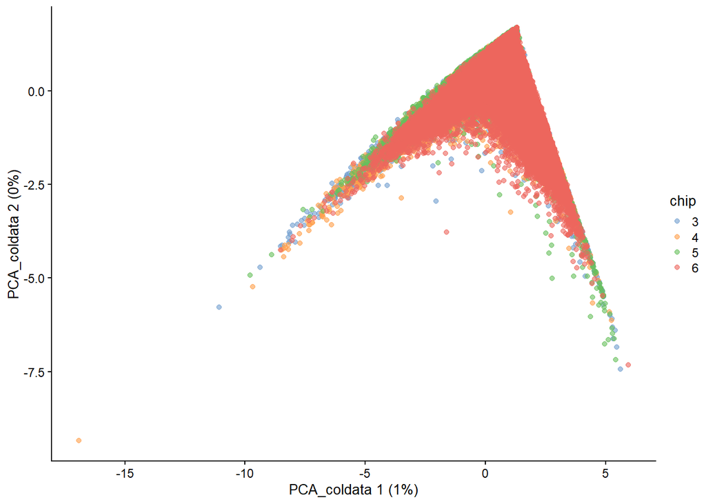

```r
plotReducedDim(sce, dimred = "PCA_coldata", colour_by = "chip")
```

### Ratio between sum and gene counts

This measures the number of detected genes per cell divided by its library size. This will be very useful to delete the cells that have low gene counts but a relatively high umi count (visible in the scatter plots).

```r
if (!file.exists(here( "processed", project, "sce_preliminary.RDS"))) {
  sce$ratio_detected_sum <- sce$detected / sce$sum
  sce$outlier_ratio <- isOutlier(sce$ratio_detected_sum, type = "both", subset = sce$chip %in% c(3:5))
}

summary(sce$ratio_detected_sum)
```

```
##     Min.  1st Qu.   Median     Mean  3rd Qu.     Max.
## 0.008078 0.323264 0.395775 0.406782 0.482403 0.878004
```

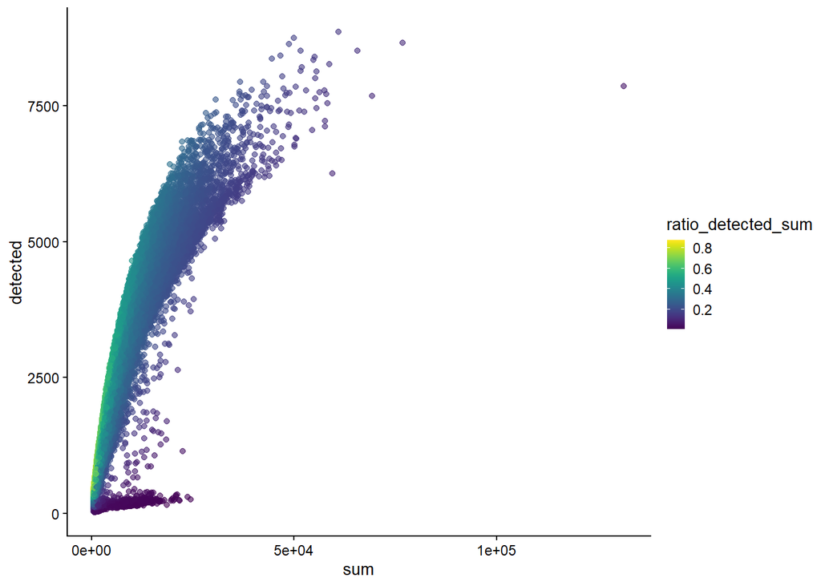

```r
plotColData(sce, x = "sum", y = "detected", colour_by = "ratio_detected_sum")
```

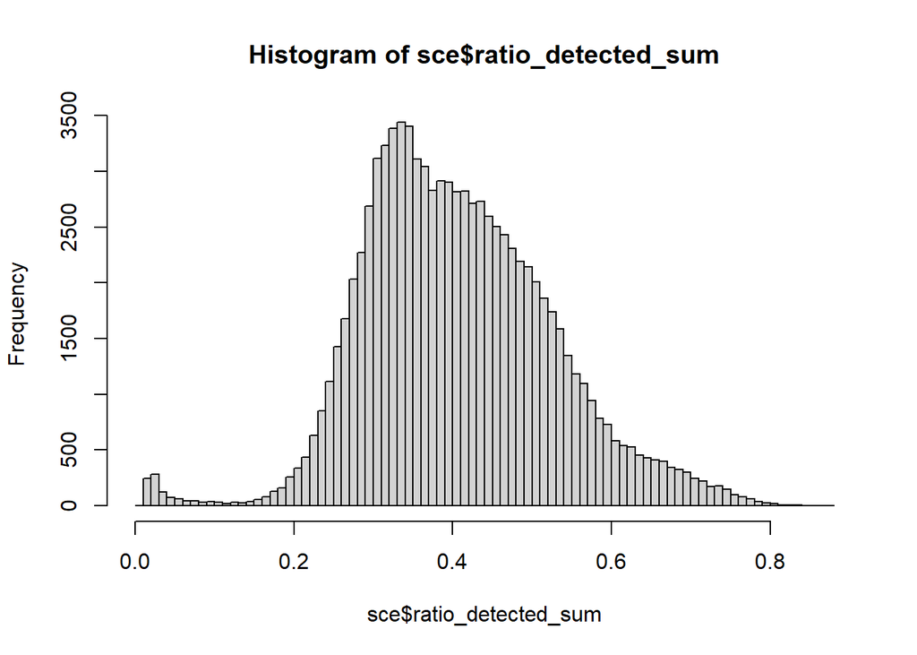

```r
# Plot an histogram with the ratio between umi and gene counts
hist(
  sce$ratio_detected_sum,
  breaks = 100
)
```

The isoutlier function can but used to find the outliers of any distribution, as far as it is roughly normal. Bellow we use it with the ratio between the number of genes expressed and the number of umi. Again, only the first 3 chips are considered to calculate the cut-offs

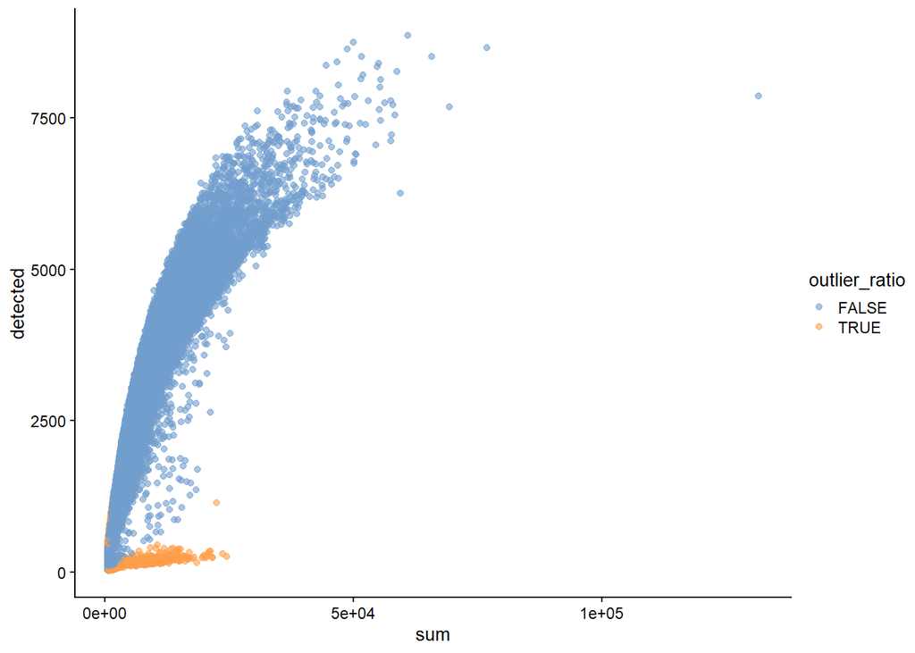

```r
# Use the is outlier function from scater to see the cutoffs suggestions
plotColData(sce, x = "sum", y = "detected", colour_by = "outlier_ratio")
```

```r
attr(sce$outlier_ratio, "thresholds")
```

```
##      lower     higher
## 0.05459917 0.72380852
```

This filters out 1532 cells.

#### Thresholds for cell filtering

The upper thresholds from the sum of umi counts is 1.9024^{4} and the lower threshold is 462 umi counts.

We will also take in consideration the detected genes/umi counts ratio, that filter out cells with relatively high umi counts but very few detected genes ( lots of copies from the same genes). And any cell with above 14.37 % mitochondrial genes.

Finally we will remove sample EKDL2660.

```r
# add label 'discard' to all cells to discard
sce$discard <- sce$outlier | sce$outlier_ratio | sce$Sample == "EKDL2660"
# save the object with all cells but with outlier parametres saved
if (!file.exists(here( "processed", project, "sce_preliminary.RDS"))) {
saveRDS(sce, here( "processed", project, "sce_preliminary.RDS"))
}
```

# Gene QC

It is typically a good idea to remove genes whose expression level is considered “undetectable”. Here we define a gene as detectable if at least two cells contain a transcript from the gene. It is important to keep in mind that genes must be filtered after cell filtering since some genes may only be detected in poor quality cells.

```r
genes_beforeqc <- dim(sce)[1]
keep_feature <- rowSums(counts(sce) > 0) > 1
sce <- sce[keep_feature, ]
genes_beforeqc - dim(sce)[1]
```

```
## [1] 8566
```

This way we deleted 8566 genes and kept 23719 genes

```r
plotHighestExprs(sce, exprs_values = "counts")
```

[output not shown]

# Create new filetered object

```r
if (!file.exists(here( "processed", project, "sce_QC_01.RDS"))) {
  sce <- sce[, sce$discard == FALSE]
  saveRDS(sce, here( "processed", project, "sce_QC_01.RDS"))
}
```

The object has 23719 genes and 58466 cells after filtering

## Session Info

**Click to expand**